# Lec08 Intro to Machine Learning

Michael Nguyen

10/24/2019

## K-means clustering

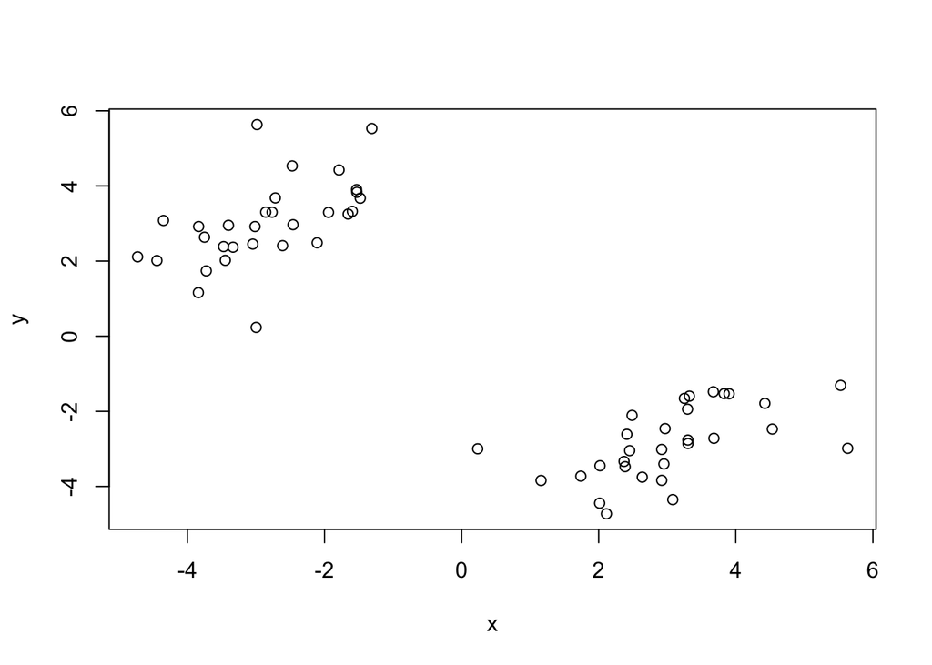

```r
# Generate some example data for clustering
tmp <- c(rnorm(30, -3), rnorm(30,3))
x <- cbind(x=tmp, y=rev(tmp))

plot (x)
```

Use the kmeans() function setting k to 2 and nstart=20 Inspect/print the results

```r
k <- kmeans(x, centers = 2, nstart = 20)
k
```

```
## K-means clustering with 2 clusters of sizes 30, 30
##
## Cluster means:
##           x         y
## 1 -2.840046  3.017840
## 2  3.017840 -2.840046
##
## Clustering vector:
##  [1] 1 1 1 1 1 1 1 1 1 1 1 1 1 1 1 1 1 1 1 1 1 1 1 1 1 1 1 1 1 1 2 2 2 2 2
## [36] 2 2 2 2 2 2 2 2 2 2 2 2 2 2 2 2 2 2 2 2 2 2 2 2 2
##
## Within cluster sum of squares by cluster:
## [1] 64.60091 64.60091
##  (between_SS / total_SS =  88.8 %)
##
## Available components:
##
## [1] "cluster"      "centers"      "totss"        "withinss"
## [5] "tot.withinss" "betweenss"    "size"         "iter"
## [9] "ifault"
```

Q. How many points are in each cluster? ->30 each Q. What ‘component’ of your result object details - cluster size?

```r
k$size
```

```
## [1] 30 30
```

- cluster assignment/membership?

```r
k$cluster
```

```
##  [1] 1 1 1 1 1 1 1 1 1 1 1 1 1 1 1 1 1 1 1 1 1 1 1 1 1 1 1 1 1 1 2 2 2 2 2
## [36] 2 2 2 2 2 2 2 2 2 2 2 2 2 2 2 2 2 2 2 2 2 2 2 2 2
```

- cluster center?

```r
k$centers
```

```
##           x         y
## 1 -2.840046  3.017840
## 2  3.017840 -2.840046
```

Plot x colored by the kmeans cluster assignment and add cluster centers as blue points

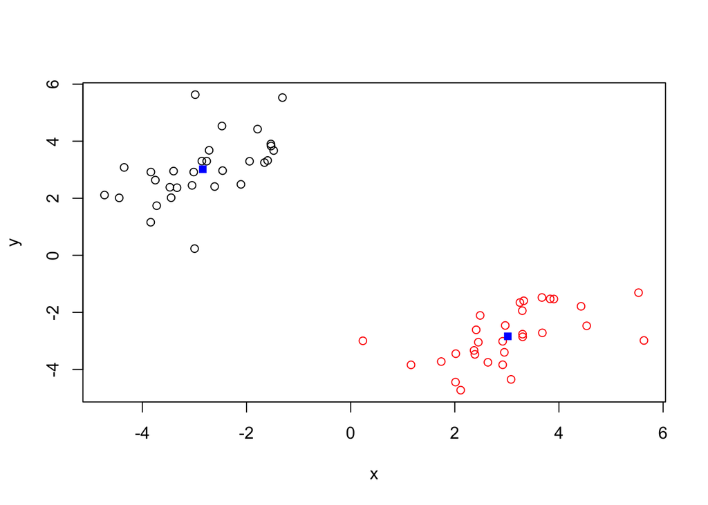

```r
plot(x, col = k$cluster)
points(k$centers, col = "blue", pch = 15)
```

## Heirarchal clustering in R

The `hclust()` function requires a distance matrix as input. You can get this from the `dist()` function

```r
# First we need to calculate point (dis)similarity # as the Euclidean distance between observations
dist_matrix <- dist(x)

# The hclust() function returns a hierarchical # clustering model
hc <- hclust(d = dist_matrix)

# the print method is not so useful here
hc
```

```
##
## Call:
## hclust(d = dist_matrix)
##
## Cluster method   : complete
## Distance         : euclidean
## Number of objects: 60
```

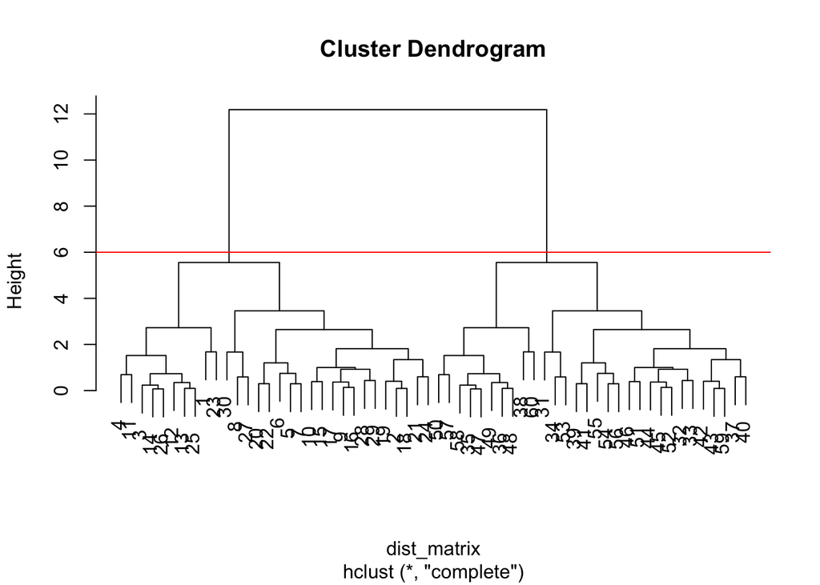

```r
plot(hc)
# There are 2 clusters. numbers < 30 on L; numbers > 30 on R

abline(h = 6, col="red")
```

```r
# cut by height h
cutree(hc, h = 6)
```

```
##  [1] 1 1 1 1 1 1 1 1 1 1 1 1 1 1 1 1 1 1 1 1 1 1 1 1 1 1 1 1 1 1 2 2 2 2 2
## [36] 2 2 2 2 2 2 2 2 2 2 2 2 2 2 2 2 2 2 2 2 2 2 2 2 2
```

```r
# can save cutree() data into variabel (grps for ex)
```

```r
cutree(hc, k =4)
```

```
##  [1] 1 2 1 1 2 2 2 2 2 2 1 1 1 1 2 2 2 2 2 2 2 2 1 2 1 1 2 2 2 2 3 3 3 3 4
## [36] 4 3 4 3 3 3 3 3 3 3 3 4 4 4 4 3 3 3 3 3 3 4 4 3 4
```

### Can cut by HEIGHT h or k

Practice

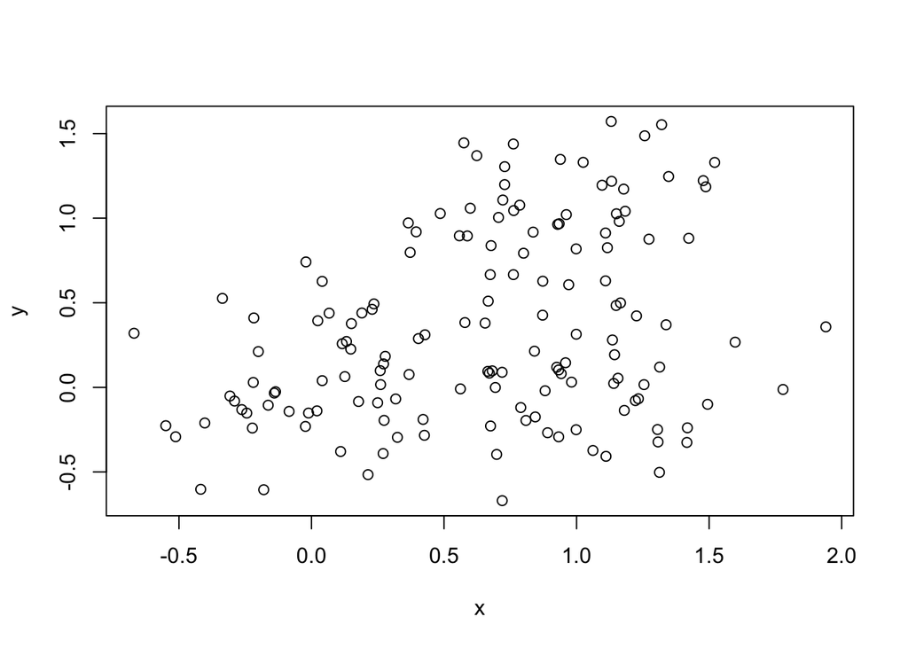

```r
# Step 1. Generate some example data for clustering
y <- rbind(
matrix(rnorm(100, mean=0, sd = 0.3), ncol = 2), # c1
matrix(rnorm(100, mean = 1, sd = 0.3), ncol = 2), # c2
matrix(c(rnorm(50, mean = 1, sd = 0.3), # c3
         rnorm(50, mean = 0, sd = 0.3)), ncol = 2))
colnames(y) <- c("x", "y")

# Step 2. Plot the data without clustering
plot(y)
```

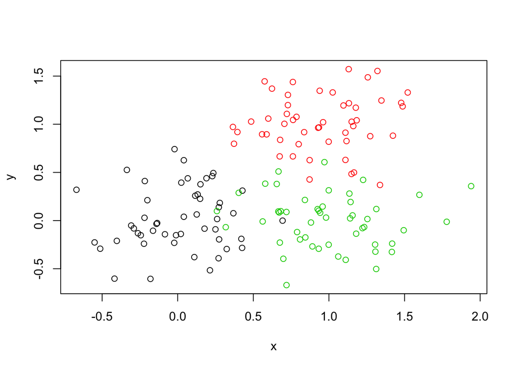

```r
# Step 3. Generate colors for known clusters (just so we can compare to hclust results)

col <- as.factor( rep(c("c1","c2","c3"), each=50) )
plot(y, col=col)
```

### kmeans(x, centers, nstart); hclust(dist(x))

```r
# K-means
kmeans(y, centers = 3, nstart = 20)
```

```
## K-means clustering with 3 clusters of sizes 48, 52, 50
##
## Cluster means:
##            x          y
## 1 0.92237713 1.04119796
## 2 0.01840603 0.02927244
## 3 1.04632086 0.00417223
##
## Clustering vector:
##   [1] 2 2 2 2 2 2 2 2 2 2 2 2 2 2 2 2 2 2 2 2 2 2 2 2 2 2 2 2 2 2 2 2 2 2 2
##  [36] 2 2 2 2 2 2 2 2 2 2 2 3 2 2 2 1 1 1 1 1 1 1 1 1 1 1 1 1 1 3 1 1 1 1 1
##  [71] 3 1 1 1 1 1 1 1 1 1 1 1 1 1 1 1 1 1 1 1 1 1 1 1 1 1 3 1 3 1 3 3 3 3 3
## [106] 3 3 3 3 3 3 1 3 2 3 3 3 3 3 3 3 3 3 3 3 3 1 3 3 3 3 3 3 3 3 3 3 3 2 3
## [141] 3 2 3 3 3 3 3 3 3 3
##
## Within cluster sum of squares by cluster:
## [1] 7.625429 8.964072 8.405609
##  (between_SS / total_SS =  72.7 %)
##
## Available components:
##
## [1] "cluster"      "centers"      "totss"        "withinss"
## [5] "tot.withinss" "betweenss"    "size"         "iter"
## [9] "ifault"
```

```r
# heirarchal clustering
hclust(dist(y))
```

```
##
## Call:
## hclust(d = dist(y))
##
## Cluster method   : complete
## Distance         : euclidean
## Number of objects: 150
```

Q. Use the dist(), hclust(), plot() and cutree() functions to return 2 and 3 clusters

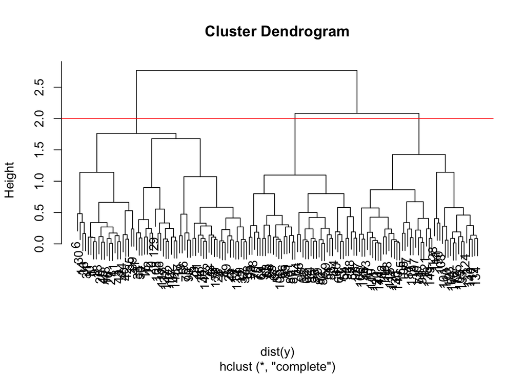

```r
# Clustering
hc2 <- hclust(dist(y))

# Draw Tree
plot(hc2)
abline(h = 2, col = "red")
```

```r
#Cut tree into clusters/groups
cutree(hc2, h = 2)
```

```
##   [1] 1 1 1 1 1 1 1 1 1 1 1 1 1 1 1 1 1 1 1 1 1 1 1 1 1 1 1 1 1 1 1 1 1 1 1
##  [36] 1 1 1 1 1 1 1 1 1 1 1 2 1 1 1 3 3 3 3 3 1 3 3 3 3 3 3 3 3 2 3 3 3 3 3
##  [71] 2 3 3 3 1 3 2 3 3 3 3 3 3 2 3 3 3 3 3 1 3 3 3 3 3 3 2 3 2 3 2 2 2 2 2
## [106] 2 1 1 2 2 2 2 1 1 2 2 2 2 2 2 2 1 2 2 2 2 2 2 1 2 2 1 2 2 2 1 2 2 1 2
## [141] 2 1 2 2 1 2 1 2 2 2
```

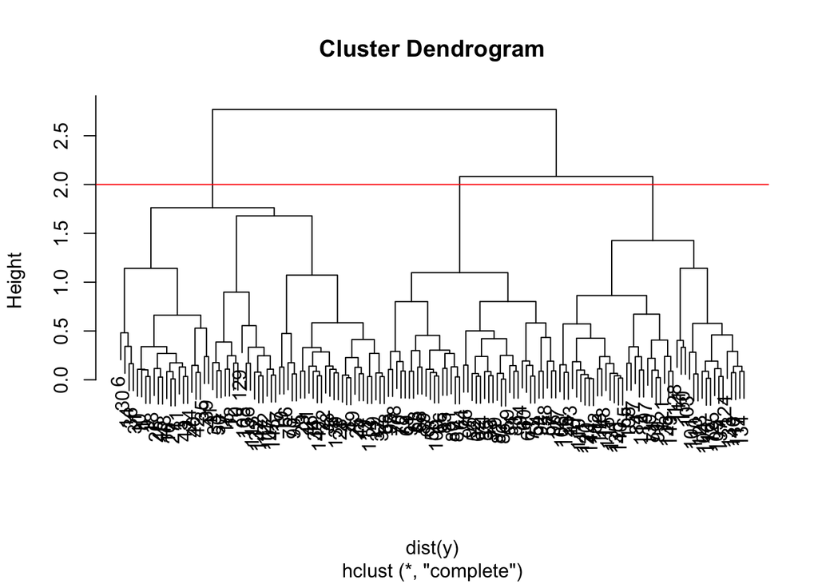

```r
# Try K instead of h
hc2 <- hclust(dist(y))
plot(hc2)
abline(h = 2, col = "red")
```

```r
grps <- cutree(hc2, k = 3)
grps
```

```
##   [1] 1 1 1 1 1 1 1 1 1 1 1 1 1 1 1 1 1 1 1 1 1 1 1 1 1 1 1 1 1 1 1 1 1 1 1
##  [36] 1 1 1 1 1 1 1 1 1 1 1 2 1 1 1 3 3 3 3 3 1 3 3 3 3 3 3 3 3 2 3 3 3 3 3
##  [71] 2 3 3 3 1 3 2 3 3 3 3 3 3 2 3 3 3 3 3 1 3 3 3 3 3 3 2 3 2 3 2 2 2 2 2
## [106] 2 1 1 2 2 2 2 1 1 2 2 2 2 2 2 2 1 2 2 2 2 2 2 1 2 2 1 2 2 2 1 2 2 1 2
## [141] 2 1 2 2 1 2 1 2 2 2
```

Q. How does this compare to your known ‘col’ groups? plot the data colored by their `hclust()` result with k = 3

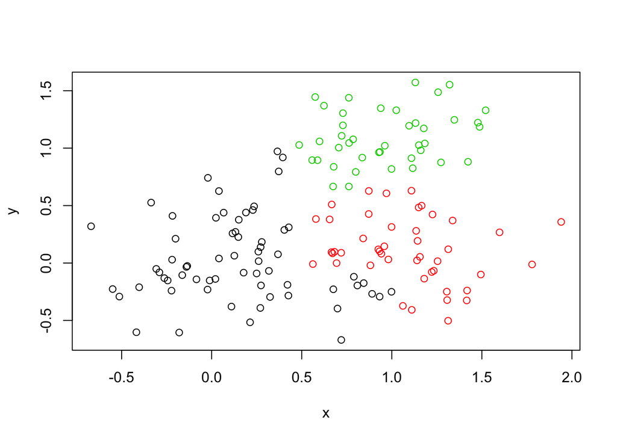

```r
plot(y, col = grps)
```

How many points in each cluster?

```r
table(grps)
```

```
## grps
##  1  2  3
## 64 45 41
```

Cross - tabulate i.e. compare your clustering result with the known answer!

```r
table(grps, col)
```

```
##     col
## grps c1 c2 c3
##    1 49  3 12
##    2  1  6 38
##    3  0 41  0
```

## PCA

### Ex/ Gene Expression

```r
mydata <- read.csv("https://tinyurl.com/expression-CSV", row.names=1)

head(mydata)
```

```
##        wt1 wt2  wt3  wt4 wt5 ko1 ko2 ko3 ko4 ko5
## gene1  439 458  408  429 420  90  88  86  90  93
## gene2  219 200  204  210 187 427 423 434 433 426
## gene3 1006 989 1030 1017 973 252 237 238 226 210
## gene4  783 792  829  856 760 849 856 835 885 894
## gene5  181 249  204  244 225 277 305 272 270 279
## gene6  460 502  491  491 493 612 594 577 618 638
```

```r
dim(mydata)
```

```
## [1] 100  10
```

```r
nrow(mydata)
```

```
## [1] 100
```

```r
#samples are columns, genes are rows
```

There are 100 genes

```r
# Let's do prcomp()

pca <- prcomp(t(mydata), scale = TRUE)
attributes(pca)
```

```
## $names
## [1] "sdev"     "rotation" "center"   "scale"    "x"
##
## $class
## [1] "prcomp"
```

Gonna focus on “x” -> `pca$x`

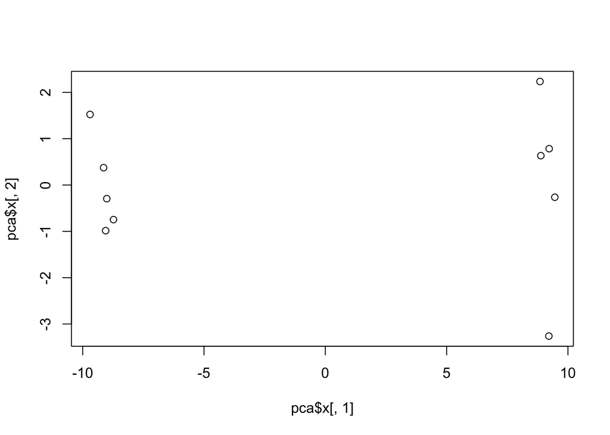

```r
# PC1 vs. PC2
plot(pca$x[,1], pca$x[,2])
```

```r
#Variance captured per PC. Present variance is often more informative to look at
pca.var <- pca$sdev^2
pca.var.per <- round(pca.var/sum(pca.var)*100, 1)
pca.var.per
```

```
##  [1] 92.6  2.3  1.1  1.1  0.8  0.7  0.6  0.4  0.4  0.0
```

### NOW let’s make a Scree Plot

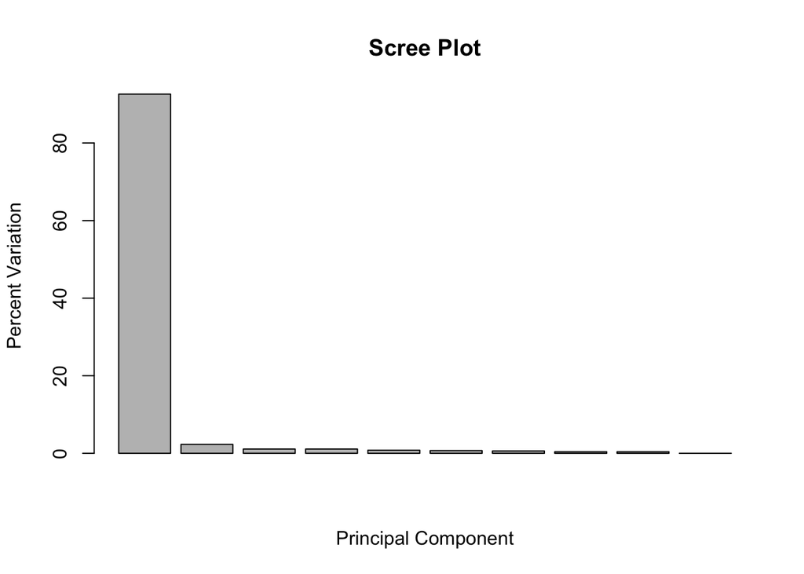

```r
barplot(pca.var.per, main="Scree Plot", xlab="Principal Component", ylab="Percent Variation")
```

Make Color vector

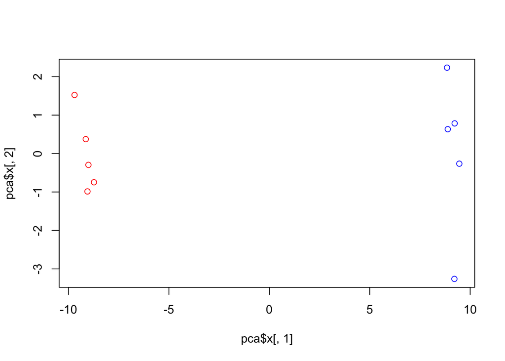

```r
# A vector of colors for wt and ko samples
plot(pca$x[,1], pca$x[,2],
     col = c("red", "red", "red", "red", "red", "blue", "blue", "blue", "blue", "blue"))
```

### A more “elegant” code for this ^

```r
# A vector of colors for wt and ko samples
colvec <- colnames(mydata)
colvec[grep("wt", colvec)] <- "red"
colvec[grep("ko", colvec)] <- "blue"

plot(pca$x[,1], pca$x[,2], col=colvec, pch=16,
     xlab=paste0("PC1 (", pca.var.per[1], "%)"),
     ylab=paste0("PC2 (", pca.var.per[2], "%)"))


identify(pca$x[,1], pca$x[,2], labels=colnames(mydata))
```

```
## integer(0)
```

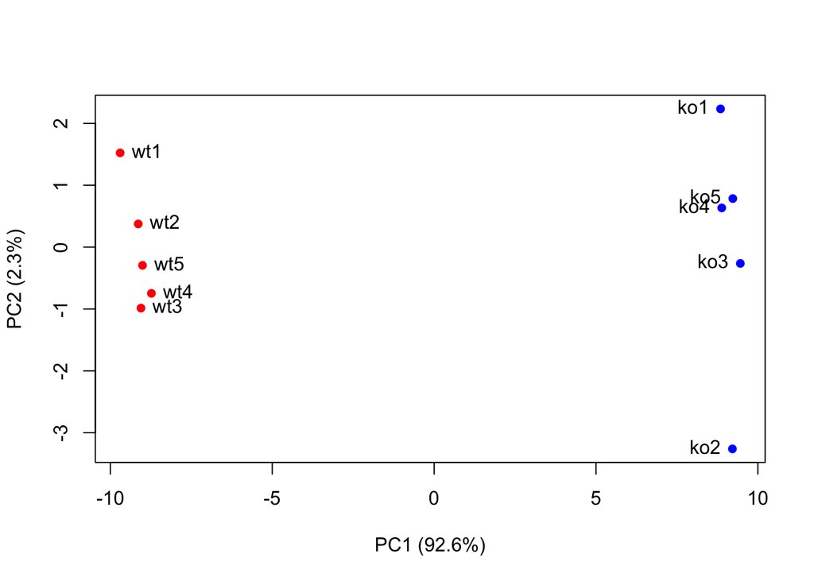

```r
text(pca$x[,1], pca$x[,2], labels = colnames(mydata), pos=c(rep(4,5), rep(2,5)))
```

# Lecture 8 Lab

## Part 1

```r
food <- read.csv("UK_foods.csv")
head(food)
```

```
##                X England Wales Scotland N.Ireland
## 1         Cheese     105   103      103        66
## 2  Carcass_meat      245   227      242       267
## 3    Other_meat      685   803      750       586
## 4           Fish     147   160      122        93
## 5 Fats_and_oils      193   235      184       209
## 6         Sugars     156   175      147       139
```

Questions

```r
# Q1. How many rows and columns are in your new data frame named x? What R functions could you use to answer this questions?

dim(food)
```

```
## [1] 17  5
```

```r
nrow(food)
```

```
## [1] 17
```

```r
ncol(food)
```

```
## [1] 5
```

```r
# 17 rows and 5 columns. R functions: dim(), nrow(), ncol().
```

```r
food <- read.csv("UK_foods.csv", row.names = 1)
head(food)
```

```
##                England Wales Scotland N.Ireland
## Cheese             105   103      103        66
## Carcass_meat       245   227      242       267
## Other_meat         685   803      750       586
## Fish               147   160      122        93
## Fats_and_oils      193   235      184       209
## Sugars             156   175      147       139
```

```r
dim(food)
```

```
## [1] 17  4
```

Q2. Which approach to solving the ‘row-names problem’ mentioned above do you prefer and why? Is one approach more robust than another under certain circumstances? - I like the first version over the “x <- x[,-1]” version because if you kept doing this it would take away the first columns. Therefore DANGEROUS.

##Spotting major differences and trends A cursory glance over the numbers in this table does not reveal much of anything. Indeed in general it is difficult to extract meaning in regard to major differences and trends from any given array of numbers. Generating regular bar-plots and various pairwise plots does not help too much either:

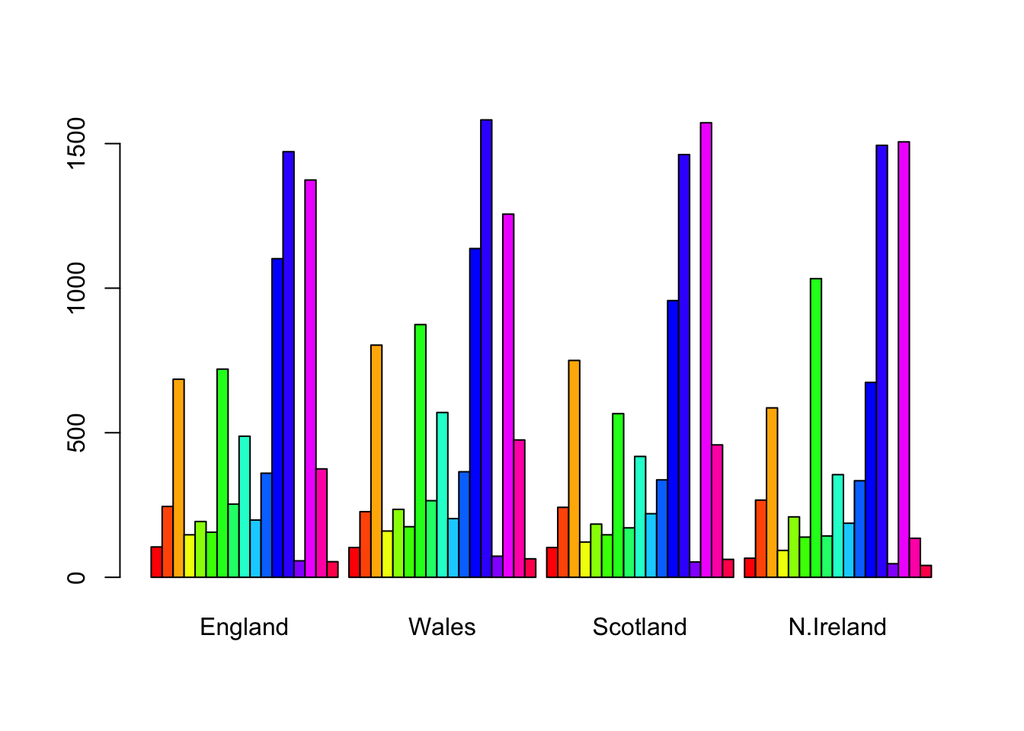

```r
barplot(as.matrix(food), beside=T, col=rainbow(nrow(food)))
```

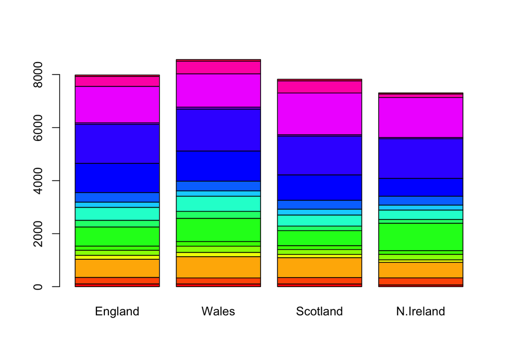

```r
# Q3: Changing what optional argument in the above barplot() function results in the following plot?
barplot(as.matrix(food), beside=F, col=rainbow(nrow(food)))
```

*NO Q4*

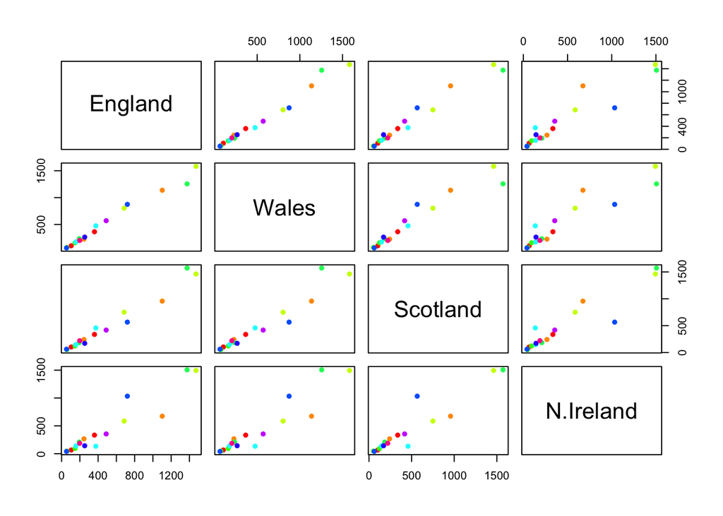

```r
# Q5: Generating all pairwise plots may help somewhat. Can you make sense of the following code and resulting figure? What does it mean if a given point lies on the diagonal for a given plot?
pairs(food, col=rainbow(10), pch=16)
```

```r
# Each country is pairwised with each food group.
# Ex/ First Row: England on y axis and other three countries on x. A linear graph shows similarities. So England is similar to Wales and Scotland
# this isn't useful if you're using several data points.
```

## PCA to the rescue

```r
pcaUK <- prcomp( t(food) )
summary(pcaUK)
```

```
## Importance of components:
##                             PC1      PC2      PC3       PC4
## Standard deviation     324.1502 212.7478 73.87622 4.189e-14
## Proportion of Variance   0.6744   0.2905  0.03503 0.000e+00
## Cumulative Proportion    0.6744   0.9650  1.00000 1.000e+00
```

–> Proportion of Variance shows us true variance. How PC1 is the biggest!

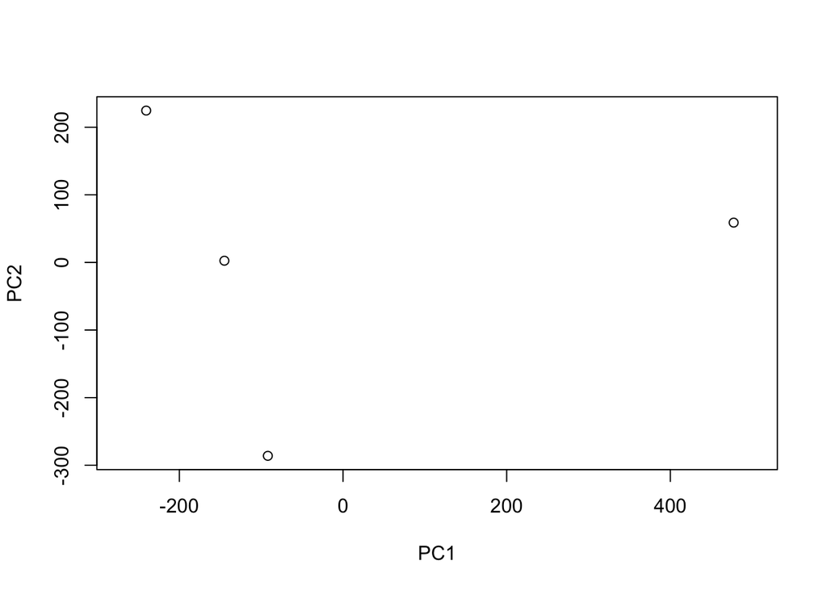

```r
# Q7. Complete the code below to generate a plot of PC1 vs PC2. The second line adds text labels over the data points.

plot(pcaUK$x[,1], pcaUK$x[,2], xlab="PC1", ylab="PC2", xlim=c(-270,500))
```

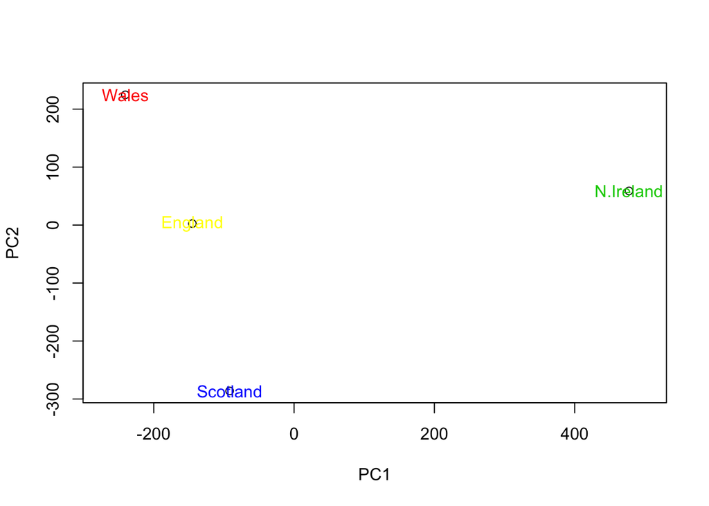

```r
# Q8. Customize your plot so that the colors of the country names match the colors in our UK and Ireland map and table at start of this document.

plot(pcaUK$x[,1], pcaUK$x[,2], xlab="PC1", ylab="PC2", xlim=c(-270,500))
text(pcaUK$x[,1], pcaUK$x[,2], colnames(food), col = c("yellow", "red", "blue", "green3"))
```

## Calculating how much variation in the original data each PC accounts for.

```r
v <- round( pcaUK$sdev^2/sum(pcaUK$sdev^2) * 100 )
v
```

```
## [1] 67 29  4  0
```

```r
z <- summary(pcaUK)
z$importance
```

```
##                              PC1       PC2      PC3          PC4
## Standard deviation     324.15019 212.74780 73.87622 4.188568e-14
## Proportion of Variance   0.67444   0.29052  0.03503 0.000000e+00
## Cumulative Proportion    0.67444   0.96497  1.00000 1.000000e+00
```

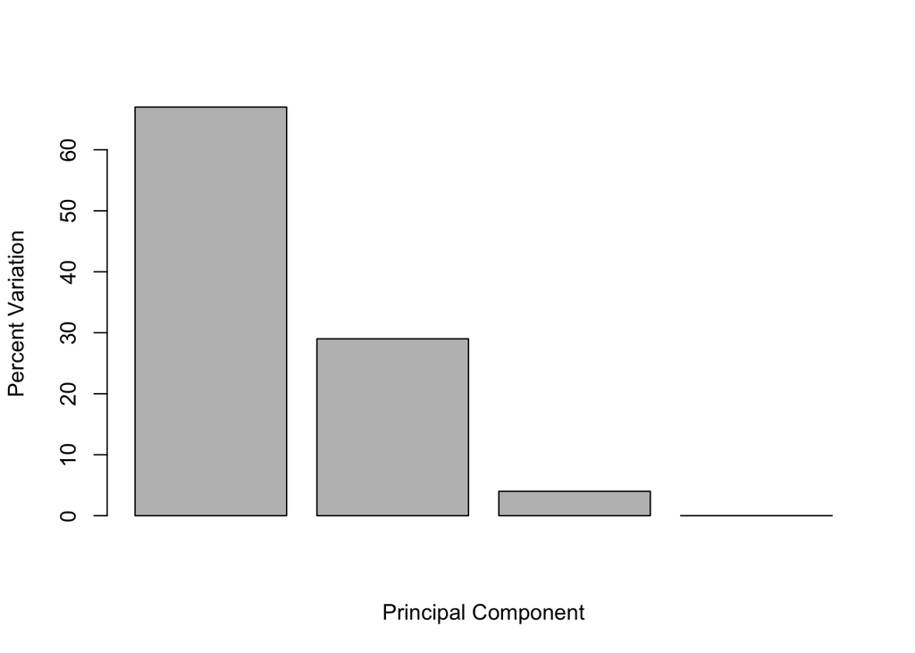

```r
barplot(v, xlab="Principal Component", ylab="Percent Variation")
```